# Lab2 Part2-Text Analysis 101 Using R

Yongjun Zhang, Ph.D.

09/01/2020

## Learning Objects

This tutorial aims to introduce basic ways to preprocess data before we model data using R. We will cover:

1. Basic intro to R
2. How to read, clean, and transform text data
3. How to preprocess data such as tokenization, removing stop words, lemmatization, stemming, and representing words in R
4. How to get basic statistics from texts using lexicon methods

In the first part of python tutorial, we have covered some basic things about how to read and save files in Python, how to recognize regEx, and how to use selenium to do webscraping.

We were able to successfully scrape the BLM protest events dataset. You can access the dataset https://yongjunzhang.com/files/tutorial/blm-data.tsv

**Here is our lab training problem set:**

> 1. You need to submit a script showing you are able to run the selenium and actually gather the data
> 2. You need to scrape the original news articles using “blm-data.tsv” dataset (it has source urls) and make a structured textual data set.
> 3. If you want to earn these extra credits, you need to turn in your scripts and dataset before Sept 8th, 6:00 PM via email.

## Lab 2 Part 2. Basic Intro to R and Preprossing Textual Data with R

#### We need to load some packages for use

```r
if (!requireNamespace("pacman"))
  install.packages('pacman')
library(pacman)
packages<-c("tidyverse","tidytext","rvest", "RSelenium",
            "tm","haven","readxl","here","knitr","stopwords")
p_load(packages,character.only = TRUE)
```

#### Load blm-data tsv file

R tidyverse package provides a series of useful data wrangling tools. You can check it here https://www.tidyverse.org/. The tidyverse package installs a number of other packages for reading data:

1. **DBI** for relational databases. You’ll need to pair DBI with a database specific backends like RSQLite, RMariaDB, RPostgres, or odbc. Learn more at https://db.rstudio.com.
2. **haven** for SPSS, Stata, and SAS data.
3. **httr** for web APIs.
4. **readxl** for .xls and .xlsx sheets.
5. **rvest** for web scraping.
6. **jsonlite** for JSON. (Maintained by Jeroen Ooms.)
7. **xml2** for XML.

```r
# read tsv file using read_csv
data <- read_tsv(url("https://yongjunzhang.com/files/tutorial/blm-data.tsv"))
# Show a table for visual check
knitr::kable(data[1:3,],cap="Black Lives Matter Protest (elephrame.com)")
```

Black Lives Matter Protest (elephrame.com)

| page_id | protest_id | protest_location | protest_start | protest_end | protest_subject | protest_participants | protest_time | protest_description | protest_urls |
| --- | --- | --- | --- | --- | --- | --- | --- | --- | --- |
| 1 | 4669 | Louisville, KY | Monday, July 20, 2020 | - Present | Subject(s): Breonna Taylor, Sgt. Jonathan Mattingly, Ofc. Brett Hankison, Ofc. Myles Cosgrov | Participant(s): 4 | Time: Continuous | Description: Hunger strike for firing of & stripping pensions from officers who killed Taylor | Source(s):##https://www.facebook.com/hungerstrikersforbreonna/videos/288546628879982/##(livestream##of##strike)##https://www.courier-journal.com/story/news/local/2020/07/19/louisville-protests-hunger-… |
| 1 | 4640 | Washington, DC | Friday, May 29, 2020 | - Present | Subject(s): General - Police Brutality, General - Racism/White Supremacy, General - Trump Administration | Participant(s): Thousands | Time: Continuous | Description: Near constant presence of demonstrators and/or displays of protest signs near White House, Lafayette Square & BLM Plaza | Source(s):##https://www.washingtonpost.com/local/dc-black-lives-matter-plaza-transformed/2020/07/20/641a1f50-c52e-11ea-8ffe-372be8d82298_story.html##https://www.washingtonpost.com/local/in-lafayette-s… |
| 1 | 4538 | Minneapolis, MN | Friday, June 5, 2020 | - Present | Subject(s): General - Police Brutality | Participant(s): 15 | Time: Continuous | Description: “Say Their Names” mock cemetery of people killed by police | Source(s):##https://theconversation.com/black-deaths-matter-the-centuries-old-struggle-to-memorialize-slaves-and-victims-of-racism-140613##https://www.mndaily.com/article/2020/06/say-their-names-cemet… |

#### Clean blm-data

Let us say, we need to create variables like state and city; we also want to clean some variables like subjects, description, etc.

```r
data <- data %>%
  # split location
  separate(protest_location,c("city","state"),sep = ",",remove = T) %>%
  # split protest start time
  separate(protest_start,c("day","date","year"),sep = ",",remove = T) %>%
  # clean subjects and participants
  mutate(
    protest_subject = str_replace(protest_subject,"Subject\\(s\\): ",""),
    protest_participants = str_replace(protest_participants,"Participant\\(s\\): ",""),
    protest_time = str_replace(protest_time,"Time: ",""),
    protest_description = str_replace(protest_description,"Description: ",""),
    protest_urls = str_replace(protest_urls,"Source\\(s\\):","")
    )
# Show a table for visual check
knitr::kable(data[1:3,],cap="Black Lives Matter Protest (elephrame.com)")
```

Black Lives Matter Protest (elephrame.com)

| page_id | protest_id | city | state | day | date | year | protest_end | protest_subject | protest_participants | protest_time | protest_description | protest_urls |
| --- | --- | --- | --- | --- | --- | --- | --- | --- | --- | --- | --- | --- |
| 1 | 4669 | Louisville | KY | Monday | July 20 | 2020 | - Present | Breonna Taylor, Sgt. Jonathan Mattingly, Ofc. Brett Hankison, Ofc. Myles Cosgrov | 4 | Continuous | Hunger strike for firing of & stripping pensions from officers who killed Taylor | ##https://www.facebook.com/hungerstrikersforbreonna/videos/288546628879982/##(livestream##of##strike)##https://www.courier-journal.com/story/news/local/2020/07/19/louisville-protests-hunger-strike-for… |
| 1 | 4640 | Washington | DC | Friday | May 29 | 2020 | - Present | General - Police Brutality, General - Racism/White Supremacy, General - Trump Administration | Thousands | Continuous | Near constant presence of demonstrators and/or displays of protest signs near White House, Lafayette Square & BLM Plaza | ##https://www.washingtonpost.com/local/dc-black-lives-matter-plaza-transformed/2020/07/20/641a1f50-c52e-11ea-8ffe-372be8d82298_story.html##https://www.washingtonpost.com/local/in-lafayette-square-visi… |
| 1 | 4538 | Minneapolis | MN | Friday | June 5 | 2020 | - Present | General - Police Brutality | 15 | Continuous | “Say Their Names” mock cemetery of people killed by police | ##https://theconversation.com/black-deaths-matter-the-centuries-old-struggle-to-memorialize-slaves-and-victims-of-racism-140613##https://www.mndaily.com/article/2020/06/say-their-names-cemetery##https… |

### Using Tidytest package to process some variables

There are a variety of processing text packages. Today we briefly introduce tidytext package. You can check herehttps://cran.r-project.org/web/packages/tidytext/vignettes/tidytext.html; This tidytext toturial heavily relies on Julia Silge and David Robinson’s work. You can also check their book Text Mining with R here https://www.tidytextmining.com/

```r
library(tidytext)

# Let us say we are interested in protest description. We need to restructure it as one-token-per-row format. The unnest_tokens function is a way to convert a dataframe with a text column to be one-token-per-row:

tidy_data <- data %>%
  # protest_urls is messay, let us get rid of it first
  select(-protest_urls) %>%
  # one token per row. This function uses the tokenizers package to separate each line into words. The default tokenizing is for words, but other options include characters, ngrams, sentences, lines, paragraphs, or separation around a regex pattern.
  unnest_tokens(word, protest_description) %>%
  # remove stop words
  anti_join(tidytext::get_stopwords("en",source="snowball")) %>%
  # you can also add your own stop words if you want
  # check here to see tibble data structure <https://tibble.tidyverse.org/>
  anti_join(tibble(word=c("no","details")),by="word")
knitr::kable(tidy_data[1:10,],cap="Black Lives Matter Protest (elephrame.com)")
```

Black Lives Matter Protest (elephrame.com)

| page_id | protest_id | city | state | day | date | year | protest_end | protest_subject | protest_participants | protest_time | word |
| --- | --- | --- | --- | --- | --- | --- | --- | --- | --- | --- | --- |
| 1 | 4669 | Louisville | KY | Monday | July 20 | 2020 | - Present | Breonna Taylor, Sgt. Jonathan Mattingly, Ofc. Brett Hankison, Ofc. Myles Cosgrov | 4 | Continuous | hunger |
| 1 | 4669 | Louisville | KY | Monday | July 20 | 2020 | - Present | Breonna Taylor, Sgt. Jonathan Mattingly, Ofc. Brett Hankison, Ofc. Myles Cosgrov | 4 | Continuous | strike |
| 1 | 4669 | Louisville | KY | Monday | July 20 | 2020 | - Present | Breonna Taylor, Sgt. Jonathan Mattingly, Ofc. Brett Hankison, Ofc. Myles Cosgrov | 4 | Continuous | firing |
| 1 | 4669 | Louisville | KY | Monday | July 20 | 2020 | - Present | Breonna Taylor, Sgt. Jonathan Mattingly, Ofc. Brett Hankison, Ofc. Myles Cosgrov | 4 | Continuous | stripping |
| 1 | 4669 | Louisville | KY | Monday | July 20 | 2020 | - Present | Breonna Taylor, Sgt. Jonathan Mattingly, Ofc. Brett Hankison, Ofc. Myles Cosgrov | 4 | Continuous | pensions |
| 1 | 4669 | Louisville | KY | Monday | July 20 | 2020 | - Present | Breonna Taylor, Sgt. Jonathan Mattingly, Ofc. Brett Hankison, Ofc. Myles Cosgrov | 4 | Continuous | officers |
| 1 | 4669 | Louisville | KY | Monday | July 20 | 2020 | - Present | Breonna Taylor, Sgt. Jonathan Mattingly, Ofc. Brett Hankison, Ofc. Myles Cosgrov | 4 | Continuous | killed |
| 1 | 4669 | Louisville | KY | Monday | July 20 | 2020 | - Present | Breonna Taylor, Sgt. Jonathan Mattingly, Ofc. Brett Hankison, Ofc. Myles Cosgrov | 4 | Continuous | taylor |
| 1 | 4640 | Washington | DC | Friday | May 29 | 2020 | - Present | General - Police Brutality, General - Racism/White Supremacy, General - Trump Administration | Thousands | Continuous | near |
| 1 | 4640 | Washington | DC | Friday | May 29 | 2020 | - Present | General - Police Brutality, General - Racism/White Supremacy, General - Trump Administration | Thousands | Continuous | constant |

```r
# let us see what stopwords we are excluding
stopwords_d <- tidytext::get_stopwords()
stopwords_d$word
```

```
##   [1] "i"          "me"         "my"         "myself"     "we"
##   [6] "our"        "ours"       "ourselves"  "you"        "your"
##  [11] "yours"      "yourself"   "yourselves" "he"         "him"
##  [16] "his"        "himself"    "she"        "her"        "hers"
##  [21] "herself"    "it"         "its"        "itself"     "they"
##  [26] "them"       "their"      "theirs"     "themselves" "what"
##  [31] "which"      "who"        "whom"       "this"       "that"
##  [36] "these"      "those"      "am"         "is"         "are"
##  [41] "was"        "were"       "be"         "been"       "being"
##  [46] "have"       "has"        "had"        "having"     "do"
##  [51] "does"       "did"        "doing"      "would"      "should"
##  [56] "could"      "ought"      "i'm"        "you're"     "he's"
##  [61] "she's"      "it's"       "we're"      "they're"    "i've"
##  [66] "you've"     "we've"      "they've"    "i'd"        "you'd"
##  [71] "he'd"       "she'd"      "we'd"       "they'd"     "i'll"
```

[output cut: 20 more lines]

## Part 3. Basic Analysis of Textual Data

### Let us get a count vector for protest description, like what are the most frequent words or bi-grams

```r
tidy_data %>%
  count(word, sort = TRUE)
```

```
## # A tibble: 3,826 x 2
##    word              n
##    <chr>         <int>
##  1 demonstration  1356
##  2 included       1330
##  3 march           975
##  4 rally           839
##  5 outside         466
##  6 national        424
##  7 game            423
##  8 anthem          418
##  9 police          379
## 10 prior           379
## # … with 3,816 more rows
```

We can further plot this! I don’t like wordcloud, so I just do a simple bar plot.

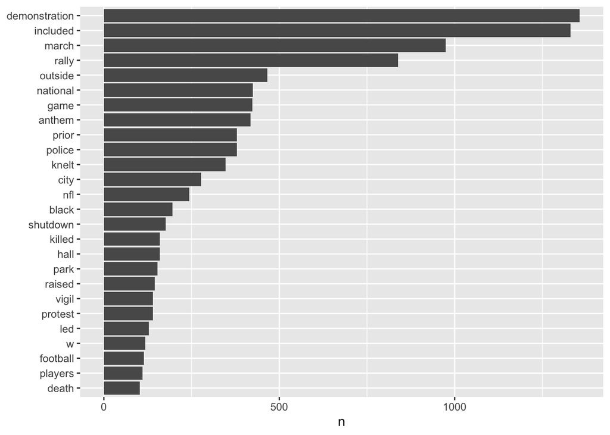

```r
library(ggplot2)

tidy_data %>%
  count(word, sort = TRUE) %>%
  filter(n > 100) %>%
  mutate(word = reorder(word, n)) %>%
  ggplot(aes(word, n)) +
  geom_col() +
  xlab(NULL) +
  coord_flip()
```

**let us get bigram**

```r
 data %>%
  select(-protest_urls) %>%
  unnest_tokens(bigram, protest_description,token = "ngrams", n = 2) %>%
  count(bigram,sort = TRUE)
```

```
## # A tibble: 11,401 x 2
##    bigram                 n
##    <chr>              <int>
##  1 for this            1333
##  2 no details          1333
##  3 this demonstration  1322
##  4 details included    1321
##  5 included for        1321
##  6 national anthem      400
##  7 prior to             379
##  8 during national      376
##  9 anthem prior         363
## 10 nfl game             235
## # … with 11,391 more rows
```

Note you can use joining functions to filter these words or ngrams… such as inner_join, anti_join, semi_join, etc.

**We can also use tidytext to build document-term matrix or tf-idf. We will cover this next time when we talk about topic modeling.**

> In the lecture, we briefly mentioned how we represent text in NLP. In Text as Data, the authors mainly summarized the approach of “bag of words” (CoW). It is just one approach to quantify what a document is about. How important a word may be in your document or in the entire corpus (collection of documents)?

> One measure of the importance of a word is its term frequency (tf). It captures the frequency of a word in a document. There are very frequent words in a document but may not be important; in English, some stopwords, like “the”, “is”, “of”, “and”, etc. So we need to remove them before analysis based on your research. But for other scholar’s that might be of their interest.

> Another way is to look at a term’s inverse document frequency (idf), which decreases the weight for commonly used words and increases the weight for words that are not used very much in a collection of documents.

> This can be combined with term frequency to calculate a term’s tf-idf (the two quantities multiplied together), the frequency of a term adjusted for how rarely it is used.

You can check text mining with R book here https://www.tidytextmining.com/tfidf.html#tfidf

```r
tidy_words <- tidy_data %>%
  count(protest_id, word, sort = TRUE)

tidy_words
```

```
## # A tibble: 24,521 x 3
##    protest_id word        n
##         <dbl> <chr>   <int>
##  1       2414 march       4
##  2       1370 square      3
##  3       2767 city        3
##  4       4501 center      3
##  5       4753 workers     3
##  6         11 w           2
##  7        204 die         2
##  8        262 police      2
##  9        303 street      2
## 10        322 march       2
## # … with 24,511 more rows
```

> The idea of tf-idf is to find the important words for the content of each document by decreasing the weight for commonly used words and increasing the weight for words that are not used very much in a collection or corpus of documents.

```r
tidy_words <- tidy_words %>%
  bind_tf_idf(word, protest_id, n)

tidy_words
```

```
## # A tibble: 24,521 x 6
##    protest_id word        n    tf   idf tf_idf
##         <dbl> <chr>   <int> <dbl> <dbl>  <dbl>
##  1       2414 march       4 0.222  1.58  0.351
##  2       1370 square      3 0.188  4.11  0.771
##  3       2767 city        3 0.188  2.88  0.540
##  4       4501 center      3 0.25   4.01  1.00
##  5       4753 workers     3 0.231  4.13  0.953
##  6         11 w           2 0.182  3.70  0.674
##  7        204 die         2 0.286  3.93  1.12
##  8        262 police      2 0.143  2.53  0.362
##  9        303 street      2 0.167  4.32  0.720
## 10        322 march       2 0.2    1.58  0.316
## # … with 24,511 more rows
```

Let us take a look at those relatively important words

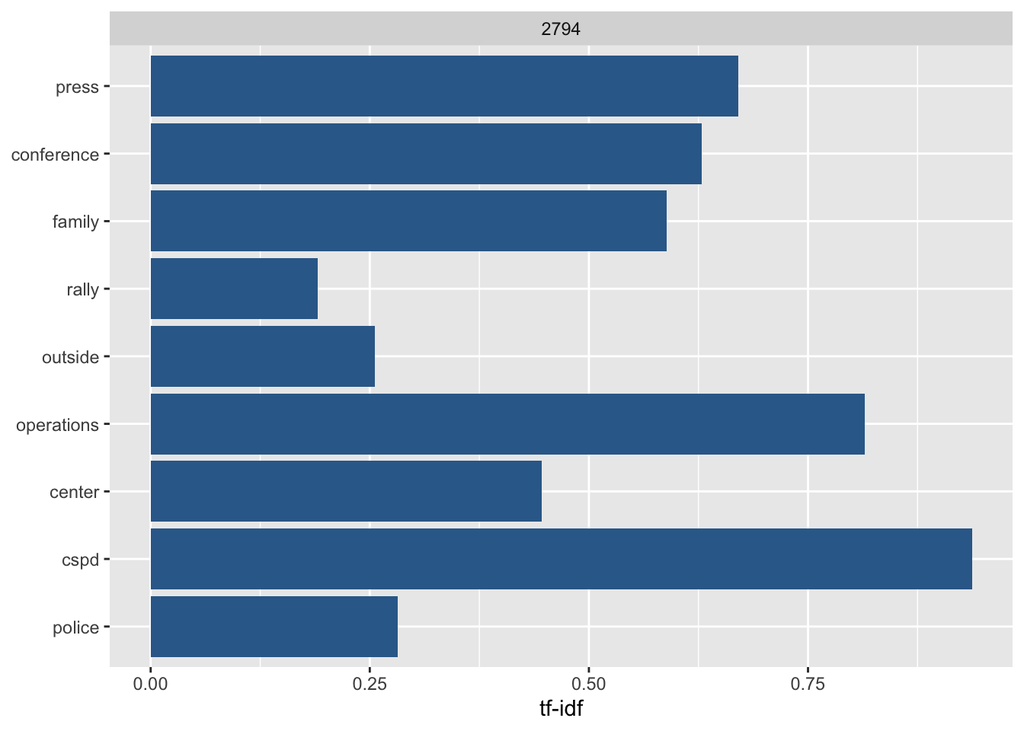

```r
tidy_words %>%
  arrange(desc(tf_idf)) %>%
  mutate(word = factor(word, levels = rev(unique(word)))) %>%
  group_by(protest_id) %>%
  filter(protest_id%in%sample(2000:5000, 4, replace=F)) %>%
  top_n(10) %>%
  ungroup() %>%
  ggplot(aes(word, tf_idf, fill = protest_id)) +
  geom_col(show.legend = FALSE) +
  labs(x = NULL, y = "tf-idf") +
  facet_wrap(~protest_id, ncol = 2, scales = "free") +
  coord_flip()
```

## Part 4. Use Stanford CoreNLP Package to do basic text processing

Check here for CORENLPhttps://stanfordnlp.github.io/CoreNLP/other-languages.html

> CoreNLP enables users to derive linguistic annotations for text, including token and sentence boundaries, parts of speech, named entities, numeric and time values, dependency and constituency parses, coreference, sentiment, quote attributions, and relations. CoreNLP currently supports 6 languages, including Arabic, Chinese, English, French, German, and Spanish. https://stanfordnlp.github.io/CoreNLP/index.html

Let us say we want to go deeper about BLM data. The BLM-DATA.TSV provides the original protest urls (news articles). We want to process those original articles to get more info.

### Let us use httr or rvest to scrape a couple of news articles for example.

```r
# create a dataset having urls, year, and ids
urls <- data %>%
  select(protest_id,state,date,protest_urls) %>%
  # let us extract all protest_urls
  mutate(protest_urls=str_replace_all(protest_urls,"^##|^#","")) %>%
  separate_rows(protest_urls,sep="##") %>%
  filter(str_detect(protest_urls,"^http"))

# only keep one url for each protest
urls1 <- urls %>%
  distinct(protest_id,.keep_all = T)

# let us take a look at the data
knitr::kable(urls1[1:5,],cap="Black Lives Matter Protest (elephrame.com)")
```

Black Lives Matter Protest (elephrame.com)

| protest_id | state | date | protest_urls |
| --- | --- | --- | --- |
| 4669 | KY | July 20 | https://www.facebook.com/hungerstrikersforbreonna/videos/288546628879982/ |
| 4640 | DC | May 29 | https://www.washingtonpost.com/local/dc-black-lives-matter-plaza-transformed/2020/07/20/641a1f50-c52e-11ea-8ffe-372be8d82298_story.html |
| 4538 | MN | June 5 | https://theconversation.com/black-deaths-matter-the-centuries-old-struggle-to-memorialize-slaves-and-victims-of-racism-140613 |
| 4522 | NC | July 9 | https://www.wral.com/fayetteville-mayor-says-protesters-must-move-from-market-house/19186797/ |
| 3937 | KY | June 5 | https://twitter.com/HayesGardner/status/1273370970686984199 |

Use httr and rvest packages to get access to articles. Note that a lot of news articles need speciall subsription to get access such as facebook, wp, etc.

rvest and httr have a lot of functions. here is an overview (credit to GITHUB:yusuzech)

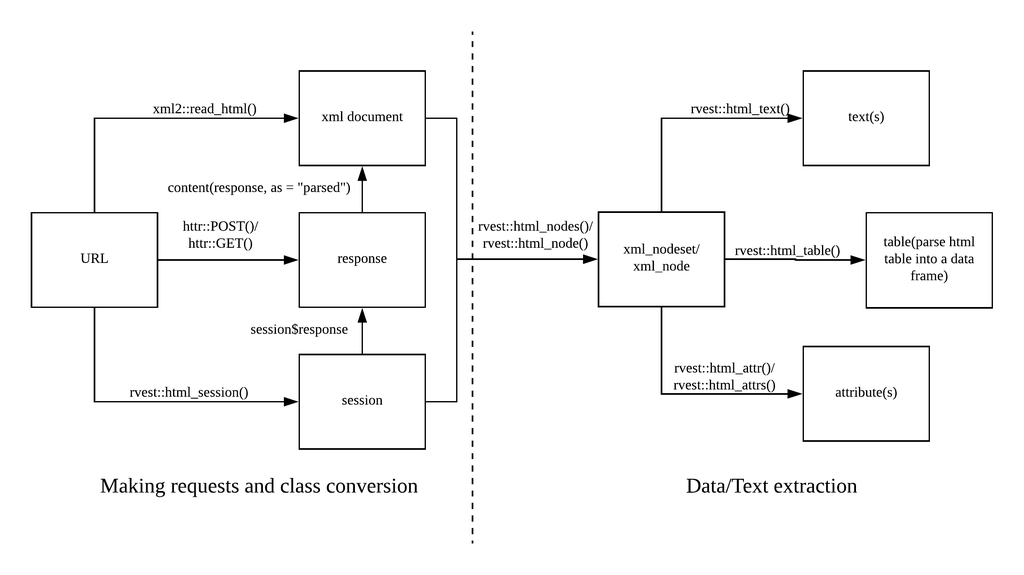

```r
knitr::include_graphics('rvest_httr.png')
```

```r
library(rvest)
library(httr)
url <- urls1$protest_urls[4]
url
```

```
## [1] "https://www.wral.com/fayetteville-mayor-says-protesters-must-move-from-market-house/19186797/"
```

```r
# rvest provides two ways of making request: read_html() and html_session()
# read_html() can parse a HTML file or an url into xml document.
# html_session() is built on GET() from httr package.

#making GET request andparse website into xml document
pagesource <- read_html(url)

#using html_session which creates a session and accept httr methods
my_session <- html_session(url)

#html_session is built upon httr, you can access response with a session
response <- my_session$response

#retrieve content as raw
content_raw <- content(my_session$response,as = "raw")
#retrieve content as text
content_text <- content(my_session$response,as = "text")
#retrieve content as parsed(parsed automatically)
content_parsed <- content(my_session$response,as = "parsed")
```

### Here let me briefly show you we can also do this in R

```r
# connect to chrome driver
driver <- RSelenium::rsDriver(browser = "chrome")
```

[output not shown]

[output not shown]

[output not shown]

[output not shown]

[output not shown]

[output not shown]

[output not shown]

[output not shown]

[output not shown]

[output not shown]

[output not shown]

[output not shown]

[output not shown]

[output not shown]

[output not shown]

[output not shown]

[output not shown]

[output cut: 8 more lines]

[output not shown]

```r
remote_driver <- driver[["client"]]
remote_driver$navigate(url)
```

```r
# retrieve the article

main_article <- remote_driver$findElement(using = "class", value="p402_premium")

text <- main_article$getElementText()
```

### Text is a messy list, you need to do some cleaning again.

```r
# let us clean those special characters like \n \t, etc.

tidy_text <- text[[1]] %>%
  # remove all whitespaces, note it is regex \t
  str_replace_all("\\s"," ") %>%
  # reove some weird punct
  str_replace_all('\\"',"") %>%
  # remove some double spaces
  str_squish %>%
  # reve spaces at the begining and end of the text
  str_trim %>%
  # lower case
  tolower()

tidy_text
```

```
## [1] "local news fayetteville mayor says protesters must move from market house tags: protest, black lives matter, fayetteville market house posted july 13, 2020 3:37 p.m. edt updated july 13, 2020 6:16 p.m. edt by gilbert baez, wral fayetteville reporter fayetteville, n.c. — after nearly a week c…
```

**VOILA, we have a nice tidy text!!!**

### Let us then use coreNLP do some text processing in R (FINALLY :))

here is a document for coreNLP in R https://cran.r-project.org/web/packages/coreNLP/coreNLP.pdf

```r
#install.packages("coreNLP")
# or devtools::install_github("statsmaths/coreNLP")
library(coreNLP)
coreNLP::downloadCoreNLP()
```

```
## [1] 0
```

```r
initCoreNLP()
```

```r
# Let us annotate our text
output = annotateString(tidy_text)
output
```

```
##
## A CoreNLP Annotation:
##   num. sentences: 26
##   num. tokens: 687
```

Once you do annotation, you can have the following information via getToken, getDependency and getSentiment

I am not a computational linguist, so we are not going to discuss details about how to read dependency trees, etc. You can check Google NLP tutorials and other complin for more details.

```r
getToken(output)
```

```
##     sentence id          token          lemma CharacterOffsetBegin
## 1          1  1          local          local                    0
## 2          1  2           news           news                    6
## 3          1  3   fayetteville   fayetteville                   11
## 4          1  4          mayor          mayor                   24
## 5          1  5           says            say                   30
## 6          1  6     protesters      protester                   35
## 7          1  7           must           must                   46
## 8          1  8           move           move                   51
## 9          1  9           from           from                   56
## 10         1 10         market         market                   61
## 11         1 11          house          house                   68
## 12         1 12           tags            tag                   74
## 13         1 13              :              :                   78
## 14         1 14        protest        protest                   80
```

[output cut: 1361 more lines]

```r
getDependency(output)
```

```
##     sentence       governor      dependent         type governorIdx
## 1          1           ROOT           says         root           0
## 2          1          mayor          local         amod           4
## 3          1          mayor           news     compound           4
## 4          1          mayor   fayetteville     compound           4
## 5          1           says          mayor        nsubj           5
## 6          1           move     protesters        nsubj           8
## 7          1           move           must          aux           8
## 8          1           says           move        ccomp           5
## 9          1           tags           from         case          12
## 10         1           tags         market     compound          12
## 11         1           tags          house     compound          12
## 12         1           move           tags    nmod:from           8
## 13         1           says              :        punct           5
## 14         1         posted        protest        nsubj          23
```

[output cut: 1399 more lines]

```r
getSentiment(output)
```

```
##    id sentimentValue    sentiment
## 1   1              0 Verynegative
## 2   2              1     Negative
## 3   3              1     Negative
## 4   4              1     Negative
## 5   5              1     Negative
## 6   6              2      Neutral
## 7   7              1     Negative
## 8   8              1     Negative
## 9   9              2      Neutral
## 10 10              1     Negative
## 11 11              1     Negative
## 12 12              2      Neutral
## 13 13              1     Negative
## 14 14              2      Neutral
## 15 15              2      Neutral
## 16 16              3     Positive
## 17 17              2      Neutral
## 18 18              1     Negative
## 19 19              1     Negative
## 20 20              1     Negative
## 21 21              1     Negative
## 22 22              1     Negative
## 23 23              1     Negative
## 24 24              1     Negative
## 25 25              1     Negative
## 26 26              1     Negative
```